# Reproducible Research: Peer Assessment 1

## Loading and preprocessing the data

In the first step, we load the data into R environment from the CSV file in the working directory.

```r
data_activity <- read.csv("D:/coursera/reproducible-research/project-1/data/activity.csv", stringsAsFactors = FALSE)
```

The data is in an appropriate form for further analysis and thus it needs no more transformation at this point.

## What is mean total number of steps taken per day?

we are interested in what is mean of number of steps taken per day. We begin with a plotting histogram of the total number the steps taken per each day. We going to ignore the missing values in the dataset.

**1.Calculate the total number of steps taken per day and Make a histogram of the total number of steps taken each day.**

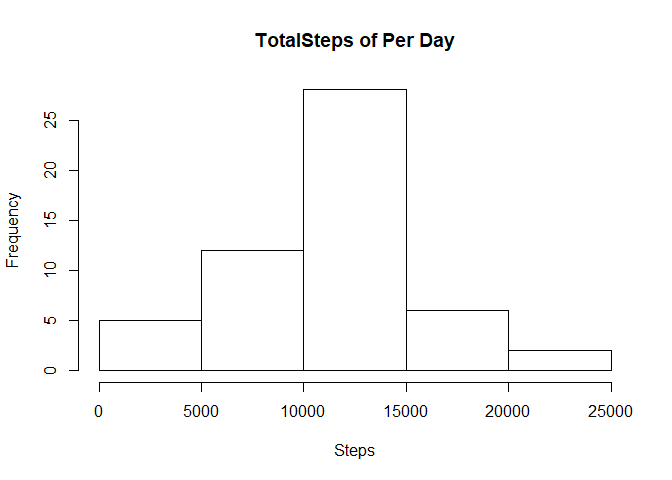

```r
totalSteps <- aggregate(steps ~ date,data= data_activity, sum, na.rm=TRUE)
hist(totalSteps$steps, main = "TotalSteps of Per Day", xlab = "Steps")
```

```r
meanSteps <- mean(totalSteps$steps)
medianSteps <- median(totalSteps$steps)
```

## What is the average daily activity pattern?

For this question I make a time series plot of the 5-minute interval (x-axis) and the average number of steps taken, averaged across all days (y-axis). I do this grouping by interval and summarising the mean of the number of steps.

**1.Make a time series plot of the 5-minute interval (x-axis) and the average number of steps taken, averaged across all days (y-axis)**

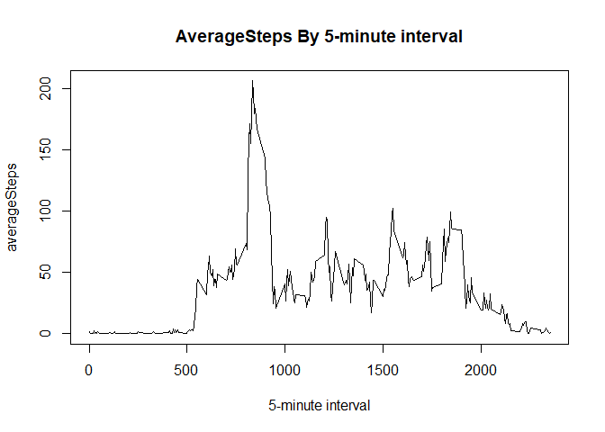

```r
aveSteps <- aggregate(steps ~ interval,data= data_activity, mean, na.rm=TRUE)
plot(aveSteps$interval, aveSteps$steps, type = "l", xlab = "5-minute interval", ylab = "averageSteps", main = "AverageSteps By 5-minute interval")
```

**2.Which 5-minute interval, on average across all the days in the dataset, contains the maximum number of steps?**

```r
maxInterval <- aveSteps$interval[which.max(aveSteps$steps)]
```

The “5-minute interval” indicator **835** contains the maximum number of steps.

## Imputing missing values

As there are a number of days/intervals where there are missing values (coded as NA). The presence of missing days may introduce bias into some calculations or summaries of the data.

**1.Calculate and report the total number of missing values in the dataset.**

```r
naNum <- sum(is.na(data_activity$steps))
```

The total number of missing values in the dataset is **2304**.

**2.Devise a strategy for filling in all of the missing values in the dataset. The strategy does not need to be sophisticated. For example, you could use the mean/median for that day, or the mean for that 5-minute interval, etc.**

I decide to use the **mean** of that 5-minute interval to fill in all of the missing values.

**3.Create a new dataset that is equal to the original dataset but with the missing data filled in.**

```r
new_activity <- data_activity
for (i in 1:length(new_activity$steps)) {
    if(is.na(new_activity[i, 1])){
        new_activity[i, 1] <- aveSteps[aveSteps$interval==new_activity[i, 3], 2]
    }
}
```

[figure not shown]

```r
new_TotalSteps <- aggregate(steps ~ date,data= new_activity, sum, na.rm=TRUE)
hist(totalSteps$steps, main = "new_TotalSteps of Per Day", xlab = "Steps")
```

```r
new_meanSteps <- mean(new_TotalSteps$steps)
new_medianSteps <- median(new_TotalSteps$steps)
```

## Are there differences in activity patterns between weekdays and weekends?

**1.Create a new factor variable in the dataset with two levels – “weekday” and “weekend” indicating whether a given date is a weekday or weekend day.**

```r
library(dplyr)
new_activity$date <- as.Date(new_activity$date)
new_activity <- mutate(new_activity, day = "weekday")
for(i in 1:length(new_activity$day)) {
    if(weekdays(new_activity[i,"date"]) == "星期日") {
        new_activity[i,"day"] <- "weekend"
    }
    else if(weekdays(new_activity[i,"date"]) == "星期六") {
        new_activity[i,"day"] <- "weekend"
    }
}
new_activity$day <- as.factor(new_activity$day)
```

**2.Make a panel plot containing a time series plot (i.e. type = “l”) of the 5-minute interval (x-axis) and the average number of steps taken, averaged across all weekday days or weekend days (y-axis). See the README file in the GitHub repository to see an example of what this plot should look like using simulated data.**

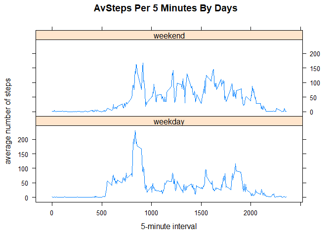

```r
avStep_byDays <- aggregate(steps ~ interval+day, data= new_activity, mean, na.rm=TRUE)
library(lattice)
xyplot(steps ~ interval | day, data = avStep_byDays, layout=c(1,2), main = "AvSteps Per 5 Minutes By Days", xlab="5-minute interval", ylab="average number of steps",type="l")
```

**Activity pattern is different between weekends and weekdays. Maybe they sit or sleep during the week.**